# EasyVisa Project

### Checking model performance on test set

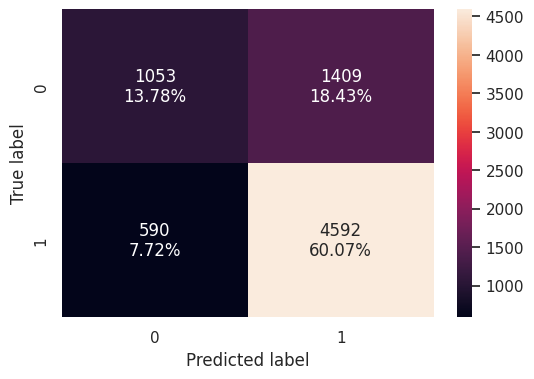

```python
# to create confusion matrix for test data
confusion_matrix_sklearn(ab_classifier, X_test, y_test)
```

- True Positives (TP): 4,592, (60.07%)
  - Model predicted the right certified candidates for 60.07% of the data.
- False Negatives (FN): 590 (7.72%)
  - Model predicted denied candidates when the candidate was certified for 7.72% of the data.
- False Positives (FP): 1,409 (18.43%)
  - Model predicted the candidate would be certified when they were denied for 18.43% of the data.
- True Negatives (TN): 1,053 (13.78%)
  - Model predicted the candidate would be denied when they were actually denied for 13.78% of the data.
- Model was able to predict 73.85% of the data into the appropriate classification.

```python
# to check performance for test data
ab_classifier_model_test_perf = model_performance_classification_sklearn(ab_classifier, X_test, y_test)
ab_classifier_model_test_perf
```

|  | Accuracy | Recall | Precision | F1 |
| --- | --- | --- | --- | --- |
| 0 | 0.73849 | 0.88614 | 0.76521 | 0.82125 |

- AdaBoost Test Performance:
  - Accuracy: 73.85%
  - Recall: 88.61%
  - Precision: 76.52%
  - F1: 82.13%

### Hyperparameter Tuning - AdaBoost Classifier

```python
# Choose the type of classifier.
abc_tuned = AdaBoostClassifier(random_state=1)

# Grid of parameters to choose from
parameters = {
    # Let's try different max_depth for base_estimator
    "base_estimator": [
        DecisionTreeClassifier(max_depth=1, class_weight="balanced", random_state=1),
        DecisionTreeClassifier(max_depth=2, class_weight="balanced", random_state=1),
    ],
    "n_estimators": np.arange(80, 101, 10),
    "learning_rate": np.arange(0.1, 0.4, 0.1),
}

# Type of scoring used to compare parameter  combinations
acc_scorer = metrics.make_scorer(metrics.f1_score)

 # to run grid search with cv = 5
grid_obj = GridSearchCV(abc_tuned, parameters, scoring=scorer, cv=5, n_jobs=-1)

# to fit the grid_obj on train data
grid_obj = grid_obj.fit(X_train, y_train)

# Set the clf to the best combination of parameters
abc_tuned = grid_obj.best_estimator_

# Fit the best algorithm to the data.
abc_tuned.fit(X_train, y_train)
```

```
AdaBoostClassifier(base_estimator=DecisionTreeClassifier(class_weight='balanced',
                                                         max_depth=1,
                                                         random_state=1),
                   learning_rate=0.1, n_estimators=90, random_state=1)
```

#### Checking model performance on training set

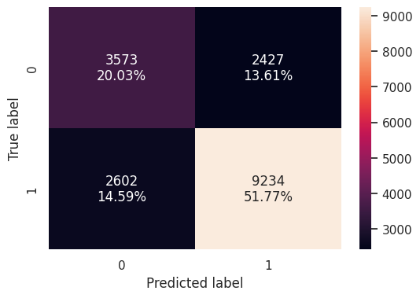

```python
# to create confusion matrix for train data on tuned estimator
confusion_matrix_sklearn(abc_tuned, X_train, y_train)
```

- True Positives (TP): 9,234 (51.77%)
  - Model predicted the right certified candidates for 51.77% of the data.
- False Negatives (FN): 2,602 (14.59%)
  - Model predicted denied candidates when the candidate was certified for 14.59% of the data.
- False Positives (FP): 2,427 (13.61%)
  - Model predicted the candidate would be certified when they were denied for 13.61% of the data.
- True Negatives (TN): 3,573 (20.03%)
  - Model predicted the candidate would be denied when they were actually denied for 20.03% of the data.
- Model was able to predict 71.80% of the data into the appropriate classification.

```python
# to check performance for train data on tuned estimator
abc_tuned_model_train_perf = model_performance_classification_sklearn(abc_tuned, X_train, y_train)
abc_tuned_model_train_perf
```

|  | Accuracy | Recall | Precision | F1 |
| --- | --- | --- | --- | --- |
| 0 | 0.71804 | 0.78016 | 0.79187 | 0.78597 |

- AdaBoost Train Performance (tuned):
  - Accuracy: 71.80%
  - Recall: 78.02%
  - Precision: 79.18%
  - F1: 78.60%